# Permutation Tests

2024-05-01

# Table 2022

| Strata | Observed | Unobserved | Metric | NMFS areas | Days fished | Vessel length (ft) | Species landed | pMax species | Landed catch (t) |
| --- | --- | --- | --- | --- | --- | --- | --- | --- | --- |
| OB HAL | 196 | 1,150 | OD | 0.015 | -0.730 | 0.073 | 0.276 | -0.003 | -2.095 |
|  |  |  | OD (%) | 1.316 | -12.919 | 0.136 | 7.584 | -0.332 | -26.236 |
|  |  |  | *p*-value | 0.667 | < 0.001* | 0.938 | 0.100 | 0.776 | < 0.001* |
| EM HAL | 133 | 525 | OD | -0.039 | -0.380 | 0.340 | 0.877 | -0.015 | 1.083 |
|  |  |  | OD (%) | -3.509 | -7.196 | 0.660 | 22.326 | -1.646 | 14.801 |
|  |  |  | *p*-value | 0.222 | 0.096 | 0.711 | < 0.001* | 0.203 | 0.052 |
| OB POT | 211 | 952 | OD | -0.011 | -1.002 | 3.832 | 0.014 | 0.009 | -2.873 |
|  |  |  | OD (%) | -1.002 | -16.531 | 5.772 | 0.566 | 0.927 | -10.485 |
|  |  |  | *p*-value | 0.694 | 0.001* | 0.043 | 0.920 | 0.133 | 0.536 |
| EM POT | 85 | 264 | OD | -0.059 | 0.407 | 5.007 | 0.459 | 0.008 | 8.840 |
|  |  |  | OD (%) | -5.334 | 7.348 | 7.868 | 17.129 | 0.816 | 46.865 |
|  |  |  | *p*-value | 0.200 | 0.517 | 0.060 | 0.022 | 0.498 | 0.002* |
| OB TRW | 210 | 515 | OD | -0.043 | -0.199 | 0.594 | -0.448 | -0.002 | -9.384 |
|  |  |  | OD (%) | -3.391 | -5.975 | 0.694 | -7.211 | -0.199 | -7.814 |
|  |  |  | *p*-value | 0.315 | 0.467 | 0.679 | 0.069 | 0.781 | 0.208 |

- Of the six metrics compared in the *OB HAL* stratum, two had low *p*-values. Observed trips in this stratum were 12.9% (0.73 days) shorter in duration and landed catch that weighed 26.2% (2.10 metric tons) less than unobserved trips.
- Of the six metrics compared in the *EM HAL* stratum, one had low *p*-values. Observed trips in this stratum landed 22.3% (0.88) more species than unobserved trips.
- Of the six metrics compared in the *OB POT* stratum, one had low *p*-values. Observed trips in this stratum were 16.5% (1.00 days) shorter in duration than unobserved trips.
- Of the six metrics compared in the *EM POT* stratum, one had low *p*-values. Observed trips in this stratum landed catch that weighed 46.9% (8.84 metric tons) more than unobserved trips.
- Of the six metrics compared in the *OB TRW* stratum, there were no metrics with low *p*-values.

# Figure 2022

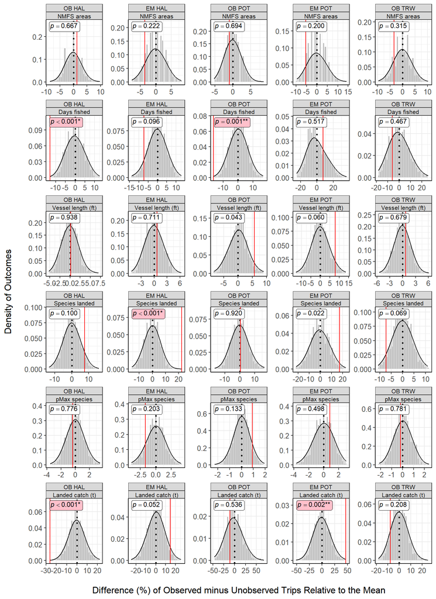

# Table 2023

| Strata | Observed | Unobserved | Metric | NMFS areas | Days fished | Vessel length (ft) | Species landed | pMax species | Landed catch (t) |
| --- | --- | --- | --- | --- | --- | --- | --- | --- | --- |
| OB HAL | 251 | 1,040 | OD | -0.023 | -0.943 | 1.050 | 0.077 | -0.018 | -1.563 |
|  |  |  | OD (%) | -1.995 | -16.085 | 1.957 | 2.114 | -1.981 | -22.439 |
|  |  |  | *p*-value | 0.431 | < 0.001* | 0.244 | 0.592 | 0.061 | 0.002* |
| EM HAL | 139 | 480 | OD | 0.005 | -0.412 | -1.830 | 0.532 | -0.013 | 0.015 |
|  |  |  | OD (%) | 0.422 | -7.247 | -3.510 | 12.948 | -1.475 | 0.201 |
|  |  |  | *p*-value | 0.912 | 0.220 | 0.044 | 0.008* | 0.328 | 0.984 |
| OB POT | 191 | 883 | OD | 0.008 | -0.723 | 4.051 | 0.087 | 0.011 | -5.566 |
|  |  |  | OD (%) | 0.758 | -12.063 | 6.361 | 3.568 | 1.123 | -20.974 |
|  |  |  | *p*-value | 0.744 | 0.029 | 0.017 | 0.500 | 0.070 | 0.278 |
| EM POT | 49 | 213 | OD | -0.045 | 0.014 | -1.979 | 0.366 | 0.002 | 4.310 |
|  |  |  | OD (%) | -4.252 | 0.256 | -3.176 | 13.596 | 0.204 | 21.481 |
|  |  |  | *p*-value | 0.500 | 0.973 | 0.455 | 0.159 | 0.862 | 0.354 |
| OB TRW | 212 | 445 | OD | -0.030 | -0.253 | 0.176 | 0.293 | -0.021 | 3.830 |
|  |  |  | OD (%) | -2.488 | -6.938 | 0.207 | 4.583 | -2.260 | 3.011 |
|  |  |  | *p*-value | 0.415 | 0.367 | 0.906 | 0.287 | 0.007* | 0.644 |

- Of the six metrics compared in the *OB HAL* stratum, two had low *p*-values. Observed trips in this stratum were 16.1% (0.94 days) shorter in duration and landed catch that weighed 22.4% (1.56 metric tons) less than unobserved trips.
- Of the six metrics compared in the *EM HAL* stratum, one had low *p*-values. Observed trips in this stratum landed 12.9% (0.53) more species than unobserved trips.
- Of the six metrics compared in the *OB POT* stratum, there were no metrics with low *p*-values.
- Of the six metrics compared in the *EM POT* stratum, there were no metrics with low *p*-values.
- Of the six metrics compared in the *OB TRW* stratum, one had low *p*-values. Observed trips in this stratum landed catch that was 2.3% more diverse than unobserved trips.

# Figure 2023

[figure not shown]